# Redundancy analysis - Part 1

Climatic variable selection, variance partitionning & candidate SNPs identification

Juliette Archambeau

14 February, 2023

Most analyses conducted in this document are based on:

- Forester et al. (2018) and the associated [vignette](https://popgen.nescent.org/2018-03-27_RDA_GEA.html).
- Capblancq and Forester (2021) and the associated [Github repository](https://github.com/Capblancq/RDA-landscape-genomics).

RDA can either be performed on *individual-based genotypes* (i.e. allele counts 0, 1 or 2) or *population-based allele frequencies*. Forester et al. (2018) suggests to use individual-based allele counts when most samples have individual coordinates and individual environment data (which depends on the resolution of the environmental data across the study area). In the present study, it seems more relevant to work with allele frequencies as several genotypes were collected at each sampling site (i.e. source population) and therefore experience the same climatic conditions. Moreover, the sample sizes varies across populations.

However, when I first conducted these analyses (in the third chapter of my PhD), I used *individual-based genotypes* because I accounted for the neutral population genetic structure with the ancestry coefficients from Jaramillo-Correa et al. (2015), which are at the genotype level (i.e. proportion of gene pool assignment for each genotype). As the population genetic structure is highly confounded with the climatic gradients across the populations sampled (see section 3), correcting for population structure with the ancestry coefficient most likely resulted in overcorrection for population structure.

In the present document, we will therefore use *population-based allele frequencies* to select the climatic variables with the stepwise selection procedure (section 2.2), identify the candidate SNPs with RDA and calculate the genomic offset.

We only use the *individual-based allele counts* for variance partitioning in section 3, in which we estimate the relative contribution of climate, population structure and geography. Population structure is either accounted for with the ancestry coefficients at the genotype level from Jaramillo-Correa et al. (2015) (section 3.1), either using the first PCs of a PCA based on *population-level allele frequencies* (section 3.2).

# 1 Downloading the data

## 1.1 Genomic data

```r
# Individual-based allele counts
# ==============================
geno_ind <- read.csv("data/DryadRepo/ImputedGenomicData_AlleleCounts_NOMAF_454clones_9817snps.csv",row.names = 1) %>%
  t() %>%
  as.data.frame()

kable_mydf(geno_ind[1:10,1:10], boldfirstcolumn = T)
```

|  | snp_2 | snp_3 | snp_4 | snp_5 | snp_6 | snp_7 | snp_8 | snp_9 | snp_10 | snp_12 |
| --- | --- | --- | --- | --- | --- | --- | --- | --- | --- | --- |
| ALT10 | 0 | 0 | 0 | 0 | 0 | 0 | 0 | 0 | 0 | 1 |
| ALT2 | 0 | 0 | 0 | 0 | 0 | 1 | 0 | 0 | 0 | 1 |
| ALT3 | 0 | 0 | 0 | 0 | 0 | 0 | 1 | 0 | 0 | 0 |
| ALT4 | 0 | 0 | 1 | 0 | 0 | 1 | 0 | 0 | 0 | 2 |
| ALT5 | 0 | 0 | 0 | 0 | 0 | 0 | 0 | 0 | 0 | 0 |
| ALT6 | 1 | 0 | 1 | 0 | 0 | 0 | 0 | 0 | 0 | 0 |
| ALT8 | 0 | 0 | 0 | 0 | 0 | 1 | 0 | 0 | 0 | 0 |
| ALT9 | 0 | 0 | 0 | 0 | 0 | 0 | 0 | 0 | 0 | 0 |
| ARM1 | 0 | 0 | 0 | 0 | 0 | 0 | 0 | 1 | 0 | 1 |
| ARM10 | 0 | 1 | 0 | 0 | 0 | 0 | 0 | 0 | 0 | 0 |

```r
# Population-based allele frequencies
# ===================================
geno_pop <- read.csv("data/DryadRepo/ImputedGenomicData_AlleleFrequencies_NOMAF_34pops_9817snps.csv",
                     row.names = 1)

kable_mydf(geno_pop[1:10,1:10] %>% round(3), boldfirstcolumn = T)
```

|  | snp_2 | snp_3 | snp_4 | snp_5 | snp_6 | snp_7 | snp_8 | snp_9 | snp_10 | snp_12 |
| --- | --- | --- | --- | --- | --- | --- | --- | --- | --- | --- |
| ALT | 0.062 | 0.000 | 0.125 | 0.000 | 0.000 | 0.188 | 0.062 | 0.000 | 0.000 | 0.250 |
| ARM | 0.000 | 0.214 | 0.143 | 0.000 | 0.000 | 0.357 | 0.000 | 0.071 | 0.000 | 0.143 |
| ARN | 0.036 | 0.071 | 0.107 | 0.000 | 0.036 | 0.464 | 0.071 | 0.000 | 0.107 | 0.036 |
| BAY | 0.308 | 0.038 | 0.154 | 0.038 | 0.000 | 0.154 | 0.038 | 0.000 | 0.038 | 0.192 |
| BON | 0.188 | 0.500 | 0.125 | 0.125 | 0.000 | 0.750 | 0.000 | 0.000 | 0.125 | 0.188 |
| CAD | 0.062 | 0.188 | 0.000 | 0.000 | 0.062 | 0.438 | 0.000 | 0.000 | 0.188 | 0.250 |
| CAR | 0.200 | 0.000 | 0.200 | 0.000 | 0.100 | 0.100 | 0.200 | 0.000 | 0.000 | 0.100 |
| CAS | 0.000 | 0.000 | 0.000 | 0.000 | 0.000 | 0.125 | 0.062 | 0.062 | 0.000 | 0.312 |
| CEN | 0.111 | 0.167 | 0.056 | 0.000 | 0.000 | 0.389 | 0.056 | 0.000 | 0.056 | 0.056 |
| COC | 0.200 | 0.133 | 0.200 | 0.000 | 0.000 | 0.533 | 0.133 | 0.033 | 0.067 | 0.100 |

The genomic dataset with *individual-based allele counts* contains 454 clones (i.e. genotypes) and 9817 SNPs. The genomic dataset with *population-based allele frequencies* contains 34 populations and 9817 SNPs.

RDA requires complete data frames (i.e., no missing data). Missing data were imputed based on the main gene pool of the clone, i.e. using the most common allele at each SNP (see report `1_FormattingGenomicData.Rmd`).

## 1.2 Climatic data

### 1.2.1 Load ClimateDT data

Climatic data comes from the [Climate Downscaling Tool (ClimateDT)](https://www.ibbr.cnr.it/climate-dt/). Annual climatic variables were extracted between 1901 and 2098.

**Reference period:** we use the annual values between 1901 and 1950 to capture the climatic conditions under which the populations have evolved.

```r
clim <- read_csv("data/DryadRepo/ClimateDT/ClimateDToutputs_Populations_1901_2098.csv",
               show_col_types = FALSE) %>%
  dplyr::filter(Year<1951) %>%  # we keep the years btw 1901 to 1950
  group_by(ID) %>% # group by population
  summarise_all("mean") %>% # take the average of the annual values for the ref period 1901-1950
  dplyr::select(-Year) %>%
  dplyr::rename(longitude=Longitude,
                latitude=Latitude,
                elevation=Elevation,
                pop=ID)

kable_mydf(clim[1:10,1:10], boldfirstcolumn = F)
```

| pop | longitude | latitude | elevation | bio1 | bio2 | bio3 | bio4 | bio5 | bio6 |
| --- | --- | --- | --- | --- | --- | --- | --- | --- | --- |
| ALT | -6.494270 | 43.28342 | 503 | 10.408 | 7.792 | 38.448 | 438.612 | 21.174 | 0.848 |
| ARM | -6.458272 | 43.30480 | 498 | 10.378 | 7.670 | 38.474 | 431.168 | 20.952 | 0.950 |
| ARN | -5.116213 | 40.19482 | 733 | 12.360 | 8.782 | 30.318 | 698.056 | 28.696 | -0.274 |
| BAY | -2.877431 | 41.52297 | 998 | 10.448 | 10.626 | 36.372 | 650.678 | 27.508 | -1.772 |
| BON | -1.660733 | 39.98588 | 1104 | 10.300 | 10.558 | 35.882 | 658.930 | 27.286 | -2.174 |
| CAD | -6.417847 | 43.53997 | 210 | 11.904 | 5.296 | 33.576 | 363.330 | 20.174 | 4.332 |
| CAR | -4.277383 | 41.17186 | 845 | 10.998 | 10.756 | 36.690 | 645.676 | 28.088 | -1.268 |
| CAS | -6.982508 | 43.50078 | 158 | 12.192 | 5.590 | 34.536 | 366.732 | 20.754 | 4.500 |
| CEN | -4.491281 | 40.27836 | 1100 | 10.160 | 9.750 | 32.956 | 694.460 | 27.054 | -2.584 |
| COC | -4.497827 | 41.25470 | 800 | 11.326 | 10.908 | 36.926 | 649.708 | 28.560 | -1.050 |

The dataset contains 34 populations and 41 climatic variables. The description of the climatic variables is available [here](https://www.ibbr.cnr.it/climate-dt/?action=fldlist).

### 1.2.2 Filtering the climatic variables

```r
# Function to identify climatic variable with a correlation coeff higher than a given threshold
identify_corr_var <- function(df,corr_threshold){

# calculate the correlation matrix among the variables
clim_cor <- df %>%
  dplyr::select(-pop,-elevation,-contains("itude")) %>%
  cor()

# attribute NA to the lower triangle and diagonal of the matrix
clim_cor[lower.tri(clim_cor,diag=T)] <- NA

# build a dataframe with the correlated variables
clim_cor <- clim_cor %>%
  melt() %>%
  na.omit() %>%
  dplyr::filter(value>corr_threshold)

}

# we want to identify variables with a correlation coefficient higher than:
corr_threshold <- 0.95

# we ran the function to identify the highly correlated variables
clim_cor <- identify_corr_var(df=clim,corr_threshold = corr_threshold)

kable_mydf(clim_cor, boldfirstcolumn = F)
```

| Var1 | Var2 | value |
| --- | --- | --- |
| bio4 | bio7 | 0.9701805 |
| bio6 | bio11 | 0.9873712 |
| bio12 | bio16 | 0.9736008 |
| bio13 | bio16 | 0.9946255 |
| bio14 | bio17 | 0.9874744 |
| bio14 | bio18 | 0.9847860 |
| bio17 | bio18 | 0.9892061 |
| bio12 | bio19 | 0.9757657 |
| bio13 | bio19 | 0.9815798 |
| bio16 | bio19 | 0.9933295 |
| bio2 | Eref | 0.9746387 |
| bio7 | Eref | 0.9699079 |
| Eref | CMD | 0.9601871 |
| bio6 | MCMT | 0.9828488 |
| bio11 | MCMT | 0.9979883 |
| bio17 | MSP | 0.9546845 |
| MOP | MSP | 0.9696582 |
| bio10 | MWMT | 0.9922852 |
| MOP | AOP | 0.9829046 |
| bio1 | GDD0 | 0.9999787 |
| bio1 | GDD5 | 0.9905435 |
| GDD0 | GDD5 | 0.9912689 |
| bio10 | GDD18 | 0.9521671 |
| bio6 | NFFD | 0.9747007 |
| bio11 | NFFD | 0.9663983 |
| MCMT | NFFD | 0.9557817 |
| bio12 | DMA | 0.9891933 |
| bio16 | DMA | 0.9652611 |
| bio19 | DMA | 0.9734653 |
| GDD5 | RMT | 0.9558895 |
| bio4 | TD | 0.9997547 |
| bio7 | TD | 0.9695395 |
| bio6 | EMT | 0.9979166 |
| bio11 | EMT | 0.9786011 |
| MCMT | EMT | 0.9724797 |
| NFFD | EMT | 0.9715065 |
| bio6 | eFFP | 0.9861818 |
| bio11 | eFFP | 0.9738148 |
| MCMT | eFFP | 0.9656716 |
| NFFD | eFFP | 0.9923228 |
| EMT | eFFP | 0.9839496 |
| bio6 | FFP | 0.9800600 |
| bio11 | FFP | 0.9607356 |
| NFFD | FFP | 0.9883974 |
| EMT | FFP | 0.9795014 |
| eFFP | FFP | 0.9966673 |

46 pairs of variables have a correlation coefficient higher than 0.95.

We remove some variables so that there are no more pairs of variables with a correlation coefficient greater than 0.95.

We also remove the variables `MOP` and `AOP` because there is no metadata for these variables on the ClimateDT website.

We remove also some variables of low biological interest for maritime past adaptation or adaptation to future climate: `PAS` (precipitation as snow between August and July), `bio13` (precipitation of the wettest month).

When estimating exposure to climate change in section 2.1, we saw that `bFFP` has weird future climatic values, so we remove it also.

We remove `EPQ` (Emberger Pluviometric Quotient) because there is very low information about this variable in the litterature and its possible influence on forest trees.

```r
clim_var_to_rm <- c("bio7","TD", # we keep bio4
                    "bio6","bio11","EMT","NFFD","eFFP", # we keep MCMT
                    "GDD0","GDD5", # we keep bio1
                    "bio17","bio18","bio14", # we keep MSP
                    "DMA","bio19","bio16", # we keep bio12
                    "bio2","CMD", # we keep Eref
                    "bio10", # we keep MWMT
                    "MOP","AOP", # we rm these variables because there is no metadata for them in the ClimateDT website!
                    "PAS","bio13", # low biological interest
                    "bFFP",
                    "EPQ"
                    )

clim <- clim %>% dplyr::select(-all_of(clim_var_to_rm))

# we check that there are no more pairs of highly correlated variables
identify_corr_var(df=clim,corr_threshold = 0.95) %>% nrow()
```

### 1.2.3 Viz

We can look at the distribution of the climatic variables.

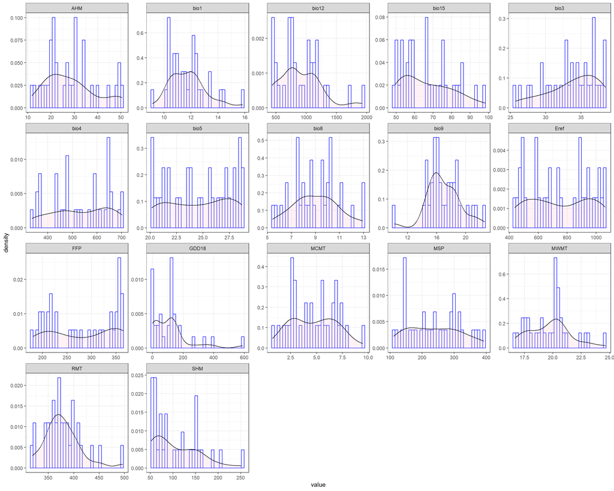

```r
p <- clim %>%
  dplyr::select(-pop,-contains("itude"),-elevation) %>%
  pivot_longer(everything(),names_to="variable") %>%
  ggplot(aes(x=value)) +
  geom_histogram(aes(y=after_stat(density)), colour="blue",fill="white",bins = 34) +
  geom_density(alpha=.2,fill="pink") +
  facet_wrap(~variable,scales="free") +
  theme_bw()

p %>% ggsave(file="figs/ExploratoryAnalyses/DistributionClimaticVariables_selected.png",
               width=15,height=12)

p
```

We also generate a correlation plot and perform a PCA to look at the correlation among the remaining climatic variables.

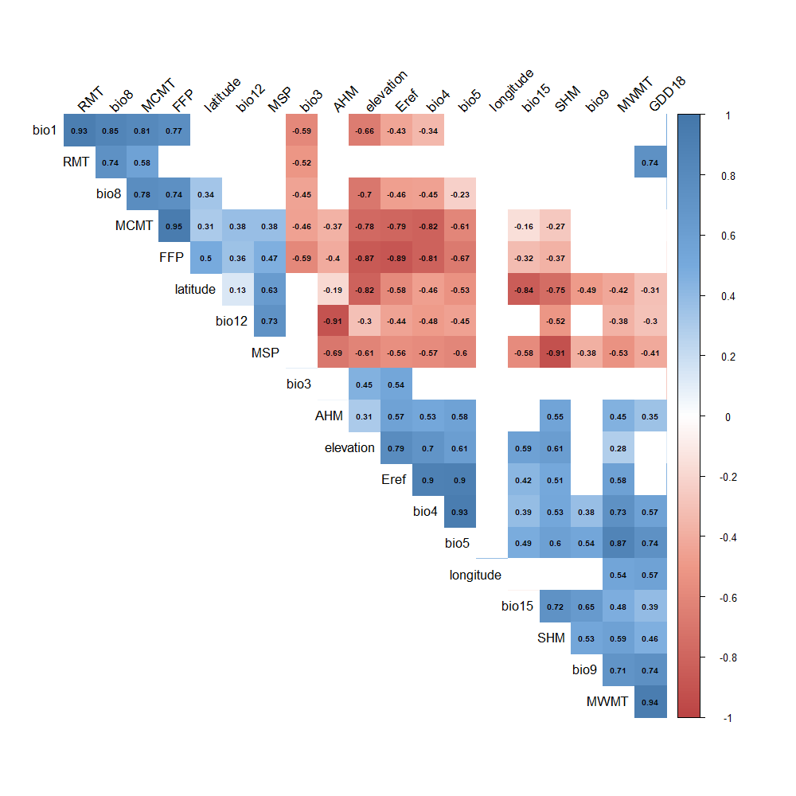

```r
# Chunk to generate figures to visualize the correlations among the climatic variables
fig_options <- list(
  path = "figs/ExploratoryAnalyses/CorrplotClimVariables.png",
  width=1000,
  height=1000,
  res=100)

make_corrplot(df = clim,
              variables = colnames(clim)[-1], # we keep long, lat, elev and clim variables
              fig_options = fig_options)
```

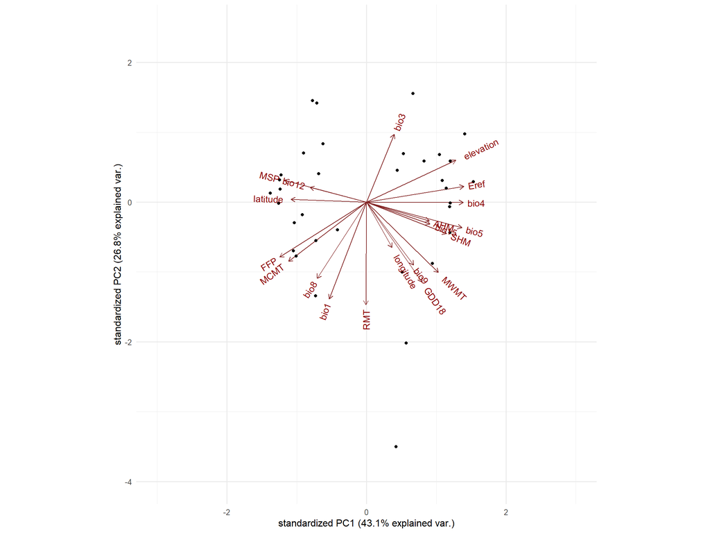

```r
# Generate a PCA
pca <- prcomp(clim[,-1], center = TRUE,scale. = TRUE)

p <- ggbiplot(pca,varname.size =4) +
  ylim(-4, 2.5) +
  xlim(-3, 3) +
  theme_minimal(base_size = 12)

ggsave(p,file="figs/ExploratoryAnalyses/PCAClimVariables.png",width=8,height=8,
       bg="white")
p
```

## 1.3 Population genetic structure

### 1.3.1 Ancestry coefficients

The proportion of gene pool assignment was estimated in Jaramillo-Correa et al. (2015) for each genotype with the *STRUCTURE* software.

```r
# We will store two datasets in a list: one with raw variables, the other one with mean-centered variables

listdf_ind <- list()

listdf_ind$df <- read.csv("data/DryadRepo/PopulationStructureCorrea2015.csv") %>%
  filter(clon %in% rownames(geno_ind)) %>% # keep the same clones as in the genomic data
  unique() %>%
  dplyr::rename(pop=prov) %>%
  left_join(clim,by="pop") %>% # merge with the climatic variables
  dplyr::select(-max.Q) %>%
  arrange(clon) # the clones have to be in the same order as in the genomic data.

# Run this line to check that the order of the clones in the genomic data and explanatory variables data is the same.
# identical(as.vector(listdf_ind$df$clon),rownames(geno_ind)) # should be TRUE

listdf_ind$df[1:10,1:14] %>%
  mutate(across(where(is.numeric), round, 2)) %>%
  kable_mydf(boldfirstcolumn = F)
```

| clon | pop | Q1 | Q2 | Q3 | Q4 | Q5 | Q6 | longitude | latitude | elevation | bio1 | bio3 | bio4 |
| --- | --- | --- | --- | --- | --- | --- | --- | --- | --- | --- | --- | --- | --- |
| ALT10 | ALT | 0.00 | 0.00 | 0.39 | 0.06 | 0.55 | 0.00 | -6.49 | 43.28 | 503 | 10.41 | 38.45 | 438.61 |
| ALT2 | ALT | 0.00 | 0.00 | 0.00 | 0.14 | 0.86 | 0.00 | -6.49 | 43.28 | 503 | 10.41 | 38.45 | 438.61 |
| ALT3 | ALT | 0.01 | 0.00 | 0.00 | 0.11 | 0.87 | 0.00 | -6.49 | 43.28 | 503 | 10.41 | 38.45 | 438.61 |
| ALT4 | ALT | 0.00 | 0.00 | 0.01 | 0.18 | 0.81 | 0.00 | -6.49 | 43.28 | 503 | 10.41 | 38.45 | 438.61 |
| ALT5 | ALT | 0.00 | 0.00 | 0.09 | 0.13 | 0.76 | 0.02 | -6.49 | 43.28 | 503 | 10.41 | 38.45 | 438.61 |
| ALT6 | ALT | 0.00 | 0.00 | 0.49 | 0.00 | 0.50 | 0.00 | -6.49 | 43.28 | 503 | 10.41 | 38.45 | 438.61 |
| ALT8 | ALT | 0.00 | 0.00 | 0.00 | 0.18 | 0.82 | 0.00 | -6.49 | 43.28 | 503 | 10.41 | 38.45 | 438.61 |
| ALT9 | ALT | 0.00 | 0.00 | 0.00 | 0.00 | 1.00 | 0.00 | -6.49 | 43.28 | 503 | 10.41 | 38.45 | 438.61 |
| ARM1 | ARM | 0.00 | 0.00 | 0.00 | 0.00 | 1.00 | 0.00 | -6.46 | 43.30 | 498 | 10.38 | 38.47 | 431.17 |
| ARM10 | ARM | 0.00 | 0.02 | 0.00 | 0.00 | 0.98 | 0.00 | -6.46 | 43.30 | 498 | 10.38 | 38.47 | 431.17 |

```r
# create df with standardized variables (ie centered and scaled)
listdf_ind$dfsc <- listdf_ind$df %>%
  dplyr::mutate(across(where(is.numeric), ~ (. - mean(.)) / sd(.)))

listdf_ind$dfsc[1:10,1:14] %>%
  mutate(across(where(is.numeric), round, 2)) %>%
  kable_mydf(boldfirstcolumn = F)
```

| clon | pop | Q1 | Q2 | Q3 | Q4 | Q5 | Q6 | longitude | latitude | elevation | bio1 | bio3 | bio4 |
| --- | --- | --- | --- | --- | --- | --- | --- | --- | --- | --- | --- | --- | --- |
| ALT10 | ALT | -0.30 | -0.23 | 0.20 | -0.61 | 1.04 | -0.37 | -0.94 | 0.28 | 0.09 | -1.16 | 1.35 | -0.88 |
| ALT2 | ALT | -0.31 | -0.23 | -0.81 | -0.44 | 1.96 | -0.38 | -0.94 | 0.28 | 0.09 | -1.16 | 1.35 | -0.88 |
| ALT3 | ALT | -0.23 | -0.23 | -0.80 | -0.49 | 1.97 | -0.38 | -0.94 | 0.28 | 0.09 | -1.16 | 1.35 | -0.88 |
| ALT4 | ALT | -0.30 | -0.23 | -0.79 | -0.35 | 1.81 | -0.38 | -0.94 | 0.28 | 0.09 | -1.16 | 1.35 | -0.88 |
| ALT5 | ALT | -0.30 | -0.23 | -0.58 | -0.46 | 1.66 | -0.26 | -0.94 | 0.28 | 0.09 | -1.16 | 1.35 | -0.88 |
| ALT6 | ALT | -0.29 | -0.23 | 0.47 | -0.74 | 0.90 | -0.38 | -0.94 | 0.28 | 0.09 | -1.16 | 1.35 | -0.88 |
| ALT8 | ALT | -0.31 | -0.23 | -0.80 | -0.35 | 1.83 | -0.38 | -0.94 | 0.28 | 0.09 | -1.16 | 1.35 | -0.88 |
| ALT9 | ALT | -0.30 | -0.23 | -0.81 | -0.74 | 2.35 | -0.38 | -0.94 | 0.28 | 0.09 | -1.16 | 1.35 | -0.88 |
| ARM1 | ARM | -0.31 | -0.23 | -0.81 | -0.74 | 2.34 | -0.37 | -0.93 | 0.29 | 0.08 | -1.18 | 1.36 | -0.94 |
| ARM10 | ARM | -0.30 | -0.13 | -0.81 | -0.74 | 2.28 | -0.37 | -0.93 | 0.29 | 0.08 | -1.18 | 1.36 | -0.94 |

### 1.3.2 PC scores

Another way to account for population structure in the RDA models is to use PCs from a *principal component analysis* (PCA) as proxies of the population evolutionary history. This is the method used in Capblancq and Forester (2021).

As advised in Capblancq and Forester (2021), the estimation of the population genetic structure should be performed on genomic data not filtered for minor allele frequencies because small genetic variations are expected to be involved in differentiating neutral genetic groups. So, we use *population-based allele frequencies* not filtered for MAF and imputed for missing data (based on the most common allele in the gene pool, see report `1_FormattingGenomicData.Rmd`).

```r
geno_pop_maf <-  read.csv("data/DryadRepo/ImputedGenomicData_AlleleFrequencies_MAF_34pops_10520snps.csv")

kable_mydf(geno_pop_maf[1:10,1:8], boldfirstcolumn = F)
```

| pop | snp_1 | snp_2 | snp_3 | snp_4 | snp_5 | snp_6 | snp_7 |
| --- | --- | --- | --- | --- | --- | --- | --- |
| ALT | 0 | 0.0625000 | 0.0000000 | 0.1250000 | 0.0000000 | 0.0000000 | 0.1875000 |
| ARM | 0 | 0.0000000 | 0.2142857 | 0.1428571 | 0.0000000 | 0.0000000 | 0.3571429 |
| ARN | 0 | 0.0357143 | 0.0714286 | 0.1071429 | 0.0000000 | 0.0357143 | 0.4642857 |
| BAY | 0 | 0.3076923 | 0.0384615 | 0.1538462 | 0.0384615 | 0.0000000 | 0.1538462 |
| BON | 0 | 0.1875000 | 0.5000000 | 0.1250000 | 0.1250000 | 0.0000000 | 0.7500000 |
| CAD | 0 | 0.0625000 | 0.1875000 | 0.0000000 | 0.0000000 | 0.0625000 | 0.4375000 |
| CAR | 0 | 0.2000000 | 0.0000000 | 0.2000000 | 0.0000000 | 0.1000000 | 0.1000000 |
| CAS | 0 | 0.0000000 | 0.0000000 | 0.0000000 | 0.0000000 | 0.0000000 | 0.1250000 |
| CEN | 0 | 0.1111111 | 0.1666667 | 0.0555556 | 0.0000000 | 0.0000000 | 0.3888889 |
| COC | 0 | 0.2000000 | 0.1333333 | 0.2000000 | 0.0000000 | 0.0000000 | 0.5333333 |

We run the PCA with the `rda` function of the `vegan` package, which performs a PCA when no predictor is included.

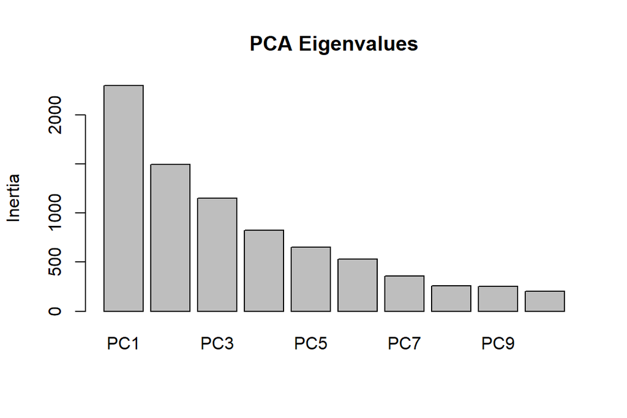

```r
pca <- rda(geno_pop_maf[,-1], scale=T)

# Screeplot of the PCA eigenvalues
screeplot(pca, type = "barplot", npcs=10, main="PCA Eigenvalues")
```

Based on the screeplot, retaining three or four PCs may be reasonable to account for neutral population structure in downstream analyses.

In our case, we keep the first three PCs.

```r
# We store two datasets in a list: one with raw variables, the other one with mean-centered variables

listdf_pop <- list()

listdf_pop$df <- data.frame(pop = geno_pop_maf[,1], # population id
                            PCs = scores(pca, choices=c(1:3), display="sites", scaling="none")) %>% #
  setNames(c("pop", "PC1", "PC2", "PC3")) %>%
  inner_join(clim, by="pop")


# extract mean and variance of the PC scores
listdf_pop$df %>%
  dplyr::select(contains("PC")) %>%
  dplyr::summarise(across(everything(),list(mean=mean,sd=sd))) %>%
  pivot_longer(everything()) %>%
  mutate(PC = str_sub(name,1,3),
         index = str_sub(name,5,-1)) %>%
  dplyr::select(-name) %>%
  pivot_wider(names_from="index",values_from="value") %>%
  kable_mydf(boldfirstcolumn = F)
```

| PC | mean | sd |
| --- | --- | --- |
| PC1 | 0 | 0.1740777 |
| PC2 | 0 | 0.1740777 |
| PC3 | 0 | 0.1740777 |

The PC scores have a mean of O but a standard deviation of 0.2, so we scale them too so that they have the same standard deviation as the climatic variables.

```r
listdf_pop$dfsc <- listdf_pop$df %>%
  dplyr::mutate(across(where(is.numeric), ~ (. - mean(.)) / sd(.)))

kable_mydf(listdf_pop$dfsc[1:8,1:9], boldfirstcolumn = F)
```

| pop | PC1 | PC2 | PC3 | longitude | latitude | elevation | bio1 | bio3 |
| --- | --- | --- | --- | --- | --- | --- | --- | --- |
| ALT | -0.6452380 | 0.9496789 | -0.4736570 | -0.7664066 | 0.4557036 | -0.0907262 | -0.9939061 | 1.2900836 |
| ARM | -0.7014790 | 1.3670334 | -0.5002025 | -0.7574290 | 0.4625773 | -0.1009337 | -1.0155691 | 1.2972625 |
| ARN | -0.1495142 | -0.0313536 | 0.2728273 | -0.4227284 | -0.5373437 | 0.3788166 | 0.4156319 | -0.9547193 |
| BAY | -0.1971864 | -0.0889407 | 0.2530315 | 0.1356090 | -0.1103165 | 0.9198115 | -0.9650221 | 0.7168719 |
| BON | 0.2691467 | 0.0008038 | 0.1874584 | 0.4390453 | -0.6045220 | 1.1362095 | -1.0718928 | 0.5815763 |
| CAD | -0.6824592 | 1.3477135 | -0.4543681 | -0.7473472 | 0.5381869 | -0.6888829 | 0.0863546 | -0.0551415 |
| CAR | -0.2861192 | -0.1620205 | 0.1897364 | -0.2135298 | -0.2232060 | 0.6074635 | -0.5678675 | 0.8046760 |
| CAS | -0.7212353 | 1.4836635 | -0.5362198 | -0.8881699 | 0.5255891 | -0.7950404 | 0.2943192 | 0.2099275 |

### 1.3.3 Population main gene pool

We extract the main gene pool for each population.

```r
# Split into dataframes specific to each population
gp_pop <- listdf_ind$df %>%
  dplyr::select(clon,pop) %>%
  left_join(read.csv("data/DryadRepo/PopulationStructureCorrea2015.csv") %>% dplyr::rename(pop=prov), by=c("pop","clon")) %>%
  group_by(pop) %>%
  group_split() %>%
  setNames(unique(sort(listdf_ind$df$pop)))

# Are there some populations for which the main gene pool is not the same for all genotypes?
gp_pop %>%
  map_dfr(\(x) {
    data.frame(Populations = unique(x$pop),
               MainGenePoolNumber = x$max.Q %>% unique() %>% length())
  }) %>%
  group_by(MainGenePoolNumber) %>%
  group_split()  %>%
  map_dfr(\(x) {
    data.frame(Populations = paste0(x$Populations, collapse =", "),
               MainGenePoolNumber = unique(x$MainGenePoolNumber))
  }) %>%
  kable_mydf(boldfirstcolumn = F)
```

| Populations | MainGenePoolNumber |
| --- | --- |
| ALT, ARM, ARN, BAY, BON, CAD, CAR, CAS, CEN, COC, COM, CUE, HOU, LAM, MAD, MIM, OLB, OLO, ORI, PET, PIA, PIE, PLE, PUE, SAC, SAL, SEG, SIE, STJ, TAM, VAL, VER | 1 |
| LEI, QUA | 2 |

The LEI and QUA populations have genotypes that belong to two different main gene pool, the main gene pool corresponding to the gene pool with the highest proportion of assignment from the STRUCTURE analysis in Jaramillo-Correa et al. (2015).

We can visualize the admixture in the following tables.

```r
gp_pop[["LEI"]] %>% kable_mydf(boldfirstcolumn = F)
```

| clon | pop | Q1 | Q2 | Q3 | Q4 | Q5 | Q6 | max.Q |
| --- | --- | --- | --- | --- | --- | --- | --- | --- |
| LEI1 | LEI | 0.001 | 0.001 | 0.514 | 0.001 | 0.483 | 0.000 | Q3 |
| LEI14 | LEI | 0.001 | 0.000 | 0.567 | 0.000 | 0.431 | 0.001 | Q3 |
| LEI15 | LEI | 0.004 | 0.008 | 0.410 | 0.034 | 0.545 | -0.001 | Q5 |
| LEI16 | LEI | 0.002 | 0.000 | 0.553 | 0.000 | 0.444 | 0.001 | Q3 |
| LEI19 | LEI | 0.002 | 0.001 | 0.562 | 0.007 | 0.403 | 0.025 | Q3 |
| LEI2 | LEI | 0.002 | 0.001 | 0.533 | 0.003 | 0.460 | 0.001 | Q3 |
| LEI21 | LEI | 0.002 | 0.001 | 0.552 | 0.001 | 0.444 | 0.000 | Q3 |
| LEI22 | LEI | 0.004 | 0.001 | 0.547 | 0.002 | 0.445 | 0.001 | Q3 |
| LEI24 | LEI | 0.001 | 0.001 | 0.562 | 0.003 | 0.432 | 0.001 | Q3 |
| LEI25 | LEI | 0.001 | 0.019 | 0.497 | 0.001 | 0.481 | 0.001 | Q3 |
| LEI26 | LEI | 0.005 | 0.000 | 0.304 | 0.001 | 0.689 | 0.001 | Q5 |
| LEI27 | LEI | 0.011 | 0.005 | 0.508 | 0.010 | 0.461 | 0.005 | Q3 |
| LEI29 | LEI | 0.005 | 0.001 | 0.430 | 0.001 | 0.562 | 0.001 | Q5 |
| LEI3 | LEI | 0.003 | 0.003 | 0.509 | 0.069 | 0.416 | 0.000 | Q3 |
| LEI30 | LEI | 0.001 | 0.000 | 0.509 | 0.003 | 0.486 | 0.001 | Q3 |
| LEI39 | LEI | 0.003 | 0.001 | 0.550 | 0.002 | 0.443 | 0.001 | Q3 |
| LEI5 | LEI | 0.025 | 0.008 | 0.438 | 0.001 | 0.527 | 0.001 | Q5 |
| LEI6 | LEI | 0.003 | 0.000 | 0.591 | 0.002 | 0.402 | 0.002 | Q3 |
| LEI8 | LEI | 0.009 | 0.001 | 0.521 | 0.002 | 0.466 | 0.001 | Q3 |
| LEI9 | LEI | 0.001 | 0.002 | 0.583 | 0.006 | 0.407 | 0.001 | Q3 |

```r
gp_pop[["QUA"]] %>% kable_mydf(boldfirstcolumn = F)
```

| clon | pop | Q1 | Q2 | Q3 | Q4 | Q5 | Q6 | max.Q |
| --- | --- | --- | --- | --- | --- | --- | --- | --- |
| QUA17 | QUA | 0.084 | 0.001 | 0.503 | 0.000 | 0.005 | 0.407 | Q3 |
| QUA33 | QUA | 0.135 | 0.001 | 0.357 | 0.001 | 0.050 | 0.456 | Q6 |
| QUA5 | QUA | 0.091 | 0.012 | 0.486 | 0.001 | 0.061 | 0.349 | Q3 |
| QUA56 | QUA | 0.118 | 0.002 | 0.498 | 0.001 | 0.001 | 0.380 | Q3 |
| QUA58 | QUA | 0.055 | 0.002 | 0.525 | 0.004 | 0.004 | 0.410 | Q3 |
| QUA61 | QUA | 0.091 | 0.005 | 0.546 | 0.001 | 0.002 | 0.355 | Q3 |
| QUA62 | QUA | 0.101 | 0.006 | 0.549 | 0.001 | 0.001 | 0.342 | Q3 |
| QUA63 | QUA | 0.100 | 0.035 | 0.490 | 0.002 | 0.012 | 0.361 | Q3 |
| QUA65 | QUA | 0.111 | 0.008 | 0.410 | 0.005 | 0.001 | 0.465 | Q6 |
| QUA76 | QUA | 0.063 | 0.009 | 0.537 | 0.003 | 0.002 | 0.386 | Q3 |
| QUA82 | QUA | 0.126 | 0.001 | 0.491 | 0.064 | 0.046 | 0.272 | Q3 |
| QUA85 | QUA | 0.094 | 0.001 | 0.532 | 0.002 | 0.055 | 0.316 | Q3 |
| QUA86 | QUA | 0.083 | 0.002 | 0.517 | 0.003 | 0.002 | 0.393 | Q3 |
| QUA87 | QUA | 0.068 | 0.001 | 0.553 | 0.001 | 0.001 | 0.376 | Q3 |
| QUA88 | QUA | 0.081 | 0.009 | 0.540 | 0.003 | 0.002 | 0.365 | Q3 |
| QUA95 | QUA | 0.082 | 0.009 | 0.498 | 0.001 | 0.007 | 0.403 | Q3 |

```r
gp_pop <- gp_pop %>%
  modify(\(x) mutate(x, mainGPpop= x$max.Q  %>% table() %>% which.max() %>% names())) %>%
  list_rbind() %>%
  dplyr::select(pop, mainGPpop) %>%
  distinct()

# We add this column to the dataframes in  listdf_pop
listdf_pop <- listdf_pop %>%
  modify(\(x) right_join(gp_pop,x,by="pop"))

saveRDS(listdf_pop, "outputs/RDA/RDA_explanatorydataframes_PopLevel.rds")

kable_mydf(listdf_pop$dfsc[1:8,1:7], boldfirstcolumn = F)
```

| pop | mainGPpop | PC1 | PC2 | PC3 | longitude | latitude |
| --- | --- | --- | --- | --- | --- | --- |
| ALT | Q5 | -0.6452380 | 0.9496789 | -0.4736570 | -0.7664066 | 0.4557036 |
| ARM | Q5 | -0.7014790 | 1.3670334 | -0.5002025 | -0.7574290 | 0.4625773 |
| ARN | Q3 | -0.1495142 | -0.0313536 | 0.2728273 | -0.4227284 | -0.5373437 |
| BAY | Q3 | -0.1971864 | -0.0889407 | 0.2530315 | 0.1356090 | -0.1103165 |
| BON | Q3 | 0.2691467 | 0.0008038 | 0.1874584 | 0.4390453 | -0.6045220 |
| CAD | Q5 | -0.6824592 | 1.3477135 | -0.4543681 | -0.7473472 | 0.5381869 |
| CAR | Q3 | -0.2861192 | -0.1620205 | 0.1897364 | -0.2135298 | -0.2232060 |
| CAS | Q5 | -0.7212353 | 1.4836635 | -0.5362198 | -0.8881699 | 0.5255891 |

# 2 Selecting the climatic variables

## 2.1 Criteria 1: exposure to climate change

For each climatic variable:

- we calculate the *mean* and *standard deviation* of its annual values for the reference period 1901-1950: $\mu_{ref}$ and $\sigma_{ref}$, respectively.
- we calculate the *Z-score* of each of its annual values $X$ for a given future period, such as *Z-score* = $(X - \mu_{ref})/\sigma_{ref}$

```r
# Time window for future climates:
min_fut_clim <- 2023
max_fut_clim <- 2050

# Do we average the z-scores across future years?
avg <- FALSE

# We load ClimateDT outputs
raw_clim <-  read_csv("data/DryadRepo/ClimateDT/ClimateDToutputs_Populations_1901_2098.csv",
               show_col_types = FALSE)

# selected clim variables
var_clim <- colnames(raw_clim)[!colnames(raw_clim) %in% c("ID","Year","Longitude","Latitude","Elevation",clim_var_to_rm)]


# calculating the z-scores
zscores <- lapply(var_clim, function(x){

past_clim <- raw_clim %>%
  dplyr::filter(Year<1951) %>%  # keep 1901 to 1950
  dplyr::select(ID,all_of(x)) %>%
  group_by(ID) %>%
  dplyr::summarise_all(list(mean="mean",sd="sd"))

# z-scores
zcores <- raw_clim %>%
  dplyr::filter(Year>min_fut_clim & Year<max_fut_clim) %>%
  dplyr::select(ID,Year,all_of(x)) %>%
  dplyr::rename(var=x) %>%
  left_join(past_clim,by="ID") %>%
  dplyr::mutate(zscore=(var-mean)/sd)

if(avg==TRUE){
  zcores <-  zcores %>%
    group_by(ID) %>%
    dplyr::summarise_at("zscore","mean")
} else{
  zcores <-  zcores %>%
    dplyr::select(ID,Year,zscore)
}

}) %>%
  setNames(var_clim) %>%
  bind_rows(.id="var")

# we sort the average z-scores (across populations and years) to determine
# which climatic variables have the highest abs(Z-scores)
abs_mean_zscore <- zscores %>%
  spread(var,zscore) %>%
  mutate_if(is.numeric,abs) %>%
  dplyr::select(all_of(var_clim)) %>%
  dplyr::summarise_all("mean") %>%
  gather(variable, value) %>%
  arrange(value)
```

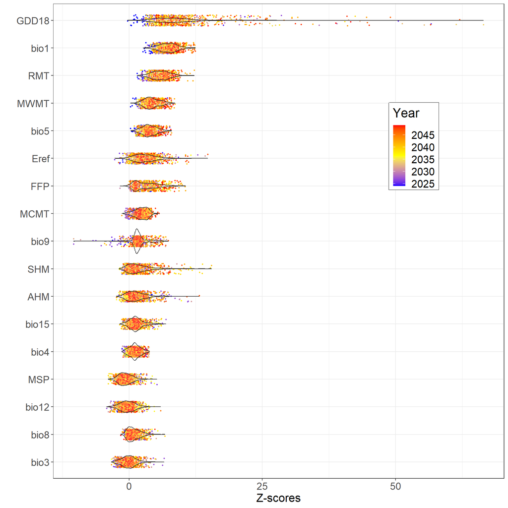

Figure 2.1: Deviation of future values of the climatic variables from the reference period 1901-1950. A point is specific to a given year and a given population

```r
# Violin plots
p <- zscores %>%
  mutate(var=factor(var,levels=c(abs_mean_zscore$variable))) %>%
  ggplot(aes(x=var, y=zscore)) +
  geom_jitter(shape=16,aes(colour = Year),position=position_jitter(0.2),size=0.5) +
  geom_violin(alpha=0.2) +
  scale_colour_gradient2(low = "blue", mid="yellow",high = "red",midpoint=(max_fut_clim+min_fut_clim)/2) +
  coord_flip() +
  xlab("") + ylab("Z-scores") +
  theme_bw() +
  theme(legend.position=c(0.8, 0.7),
        legend.title = element_text(size = 18),
        legend.text = element_text(size = 15),
        axis.text = element_text(size = 14),
        axis.title = element_text(size=16),
        legend.box.background = element_rect(colour = "black"))

p %>% ggsave(file="figs/ExploratoryAnalyses/ExposureClimateChange.png",
             width=10,height=10)
p
```

*Precipitation*-related variables show *lower deviations* from their distribution under the reference period 1901-1950. Moreover, they do not show a consistent decrease across years and populations.

**Notes on the graph interpretation:** Figure 2.1 quantifies the relative deviations of the values of the climate variables from their distribution over the reference period 1901-1950. The highest deviations of temperature-related variables do not imply that populations will be less affected by future changes in precipitation than in temperatures. Indeed, for some climate variables, even minor changes can severely affect populations. For example, some populations may already be suffering from summer droughts and even a small decrease in precipitation could have dramatic consequences.

## 2.2 Criteria 2: a predictive approach

To select the climatic variables, we may also use a *predictive approach* using *RDA with stepwise selection*, where the goal is to *maximize the genetic variance* explained by a set of predictors (Capblancq and Forester 2021).

For that, we use the selection procedure from the `ordiR2step` function of the package `vegan`.

We have to specify two models:

- a *null* model where the response is explained only by an intercept.
- a *full* model including all variables.

In the `ordi2step` function, the default criteria for including the variables is based on both *significance* of the newly selected variables, and the comparison of *adjusted variation* ($R^2_{adj}$) explained by the selected variables to $R^2_{adj}$ explained by the full model. If the new variable is not significant or the $R^2_{adj}$ of the model including this new variable does not exceed the $R^2_{adj}$ of the full model, the selection procedure stops.

We use the following stopping criteria: variable significance of p < 0.01 using 1000 permutations, and the $R^2_{adj}$ of the full model.

```r
# How many iterations of the stepwise selection procedure do we perform?
nbmodels <- 100
```

We perform 100 iterations of the stepwise selection procedure.

```r
# we standardize the climatic variables
climsc <- clim %>% dplyr::mutate(across(where(is.numeric), ~ (. - mean(.)) / sd(.)))

# null model
rda_null <- rda(geno_pop ~ 1, climsc)

# formula full model
formula_full_model <- colnames(climsc)[!colnames((climsc)) %in% c("pop","elevation","latitude","longitude")] %>%
  paste(collapse= " + ") # climatic variables
formula_full_model <- paste0("geno_pop ~ ",formula_full_model) %>% as.formula()

# full model
rda_full <- rda(formula_full_model, climsc)

# Stepwise selection with ordiR2step function
sumstepwise <- lapply(1:nbmodels, function(x) {
  mod <- ordiR2step(rda_null, rda_full, Pin = 0.01, R2permutations = 1000, R2scope = T)
  return(names(mod$CCA$envcentre))}) %>%
  setNames(paste0("model",1:nbmodels)) %>%
  ldply(function(x) data.frame(variables=x),.id="models") %>%
  dplyr::summarise(count(variables)) %>%
  setNames(c("variable","count"))

saveRDS(sumstepwise,file=paste0("outputs/VariableSelection/SummaryStepwiseSelection_PopLevel_",nbmodels,"models.rds"))
```

```r
sumstepwise <- readRDS(file=paste0("outputs/VariableSelection/SummaryStepwiseSelection_PopLevel_",nbmodels,"models.rds"))

kable_mydf(sumstepwise, boldfirstcolumn = F)
```

| variable | count |
| --- | --- |
| bio15 | 100 |
| bio3 | 60 |
| bio4 | 100 |

According to the stepwise selection procedure, the climatic variables that maximize the variance of the genomic data are:

- `bio15`: precipitation seasonality (coefficient of Variation).
- `bio3`: isothermality (`bio2`/`bio7`) (x100) (index) with `bio2` the mean diurnal range (mean of monthly (max temp - min temp)) and `bio7` the temperature annual range (`bio5`-`bio6`, with `bio5` the max temperature of warmest month and `bio6` the minimum temperature of the coldest month).
- `bio4`: temperature seasonality (standard deviation x100) (in °C).

## 2.3 Criteria 3: biological relevance to the study goals

Study goals:

- *evaluate* the genomic offset predictions with different methods.
- provide *GO estimates* for the studied populations to identify populations that will show the highest disruption of their current gene-environment relationships (those estimates will be provided based on the ‘best performing’ genomic offset predictions in the evaluation part).

It may be relevant not to select the same climatic variables for the different study goals and evaluation methods.

### 2.3.1 Climatic variables relevant for the evaluation part

> Evaluating genomic offset predictions with mortality data from common gardens after a strong summer drought

Differences among populations in their seedling survival in common gardens after a strong summer drought is likely to be mainly driven by their differences in adaptation to drought conditions. So, it may be relevant to estimate a genomic offset based only on climatic variables capturing summer droughts, aka a *summer-drought genomic offset* (ie *summer drought GO*).

> Evaluating genomic offset predictions with height data from common gardens

Height of young trees in common gardens is likely to be impacted by both winter and summer conditions, and both temperature and precipitation conditions. So it makes sense to evaluate GO predictions based on climatic variables capturing both temperature and precipitation conditions across the whole year (ie *global-climate genomic offset*, *global-climate GO*).

However, it may still be interesting to compare height in common gardens with the *summer-drought GO* predictions. If the *summer-drought GO* predictions are more associated with height in common gardens than *global-climate GO* predictions, it could mean that height is mostly impacted by summer conditions in the studied common gardens.

> Evaluating genomic offset predictions with mortality data from natural populations

In natural populations, climate change can *directly* impact tree mortality through more and more frequent and intense summer droughts. In contrast, an increase in winter temperatures is highly unlikely to directly impact the death of adult trees. Therefore, to determine whether current mortality rates in natural populations may be attributed to maladaptation to summer drought conditions, it may be relevant to evaluate the association between *summer-drought GO* predictions and mortality rates in National Forest Inventory plots.

On the other hand, increased temperatures in winter can benefit to pests and pathogens, which can indirectly impact tree death. In such a case, it may also be relevant to evaluate the association between mortality rates in NFI plots and *global-climate GO* predictions considering both winter and summer climatic conditions. Note that in the NFI, a tree is not counted as dead if its death is attributed to pests. However, mortality is a multifactorial process and it can be very difficult (if not impossible) to determine the relative contributions of climate, pests and other factors to tree death.

> Evaluating genomic offset predictions with predictions from ecophysiological models

I have to read the paper of Cailleux-Petit et al. to determine whether it is relevant to evaluate both *summer drought GO* and *global-climate GO* predictions.

### 2.3.2 Climatic variables relevant for providing GO predictions

According to previous studies, maritime pine populations show strong patterns of adaption to temperatures, and especially cold temperatures (eg (Grivet et al. 2011)). Under climate change, cold temperatures are expected to increase in average at the location of the studied populations (Figure 2.1). An increase in cold temperatures is unlikely to directly negatively impact the fitness of adult trees but it may impact the survival of young trees, the reproductive ability and the impact of pests and pathogens.

Thus, for the second objective of this paper (which is to provide GO estimates for the studied populations), whether or not to include winter conditions in GO predictions is a tricky question, for which there is probably no correct answer.

In this paper, we will follow the following workflow:

- if the predictions of *summer-drought GO* or *global-climate GO* are consistently better across the different evaluation methods, then we will provide these GO predictions for the studied populations.
- if the predictions of *summer-drought GO* or *global-climate GO* are not consistently better across the different evaluation parts, then we will provide both the *summer-drought GO* or *global-climate GO* predictions for the studied populations.

## 2.4 Selected variables

### 2.4.1 Summer-drought climatic variables

Selected variables:

`MWMT` will increase a lot under climate change => strong exposure to climate change (2.1).

```r
## Selected summer-drought variables
drought_var <- list(name="Summer-drought variables",
                   code="Droughtvar",
                   variables=c("MSP","MWMT"))
```

### 2.4.2 Global-climate variables

Selected variables:

- `bio1`: mean annual temperature (in °C).
- `bio12`: annual precipitation (in mm).
- `bio15`: precipitation seasonality (coefficient of Variation).
- `bio3`: isothermality (`bio2`/`bio7`) (x100) (index) with `bio2` the mean diurnal range (mean of monthly (max temp - min temp)) and `bio7` the temperature annual range (`bio5`-`bio6`, with `bio5` the max temperature of warmest month and `bio6` the minimum temperature of the coldest month).
- `bio4`: temperature seasonality (standard deviation x100) (in °C).

`bio1` will increase a lot under climate change => strong exposure to climate change (2.1).

```r
## Selected global-climate variables
global_var <- list(name="Global-climate variables",
                   code="GCvar",
                   variables=c("bio1","bio12","bio15","bio3","bio4"))
```

### 2.4.3 Viz correlation

We can look at the correlation among variables and with the PCs scores and geographic variables.

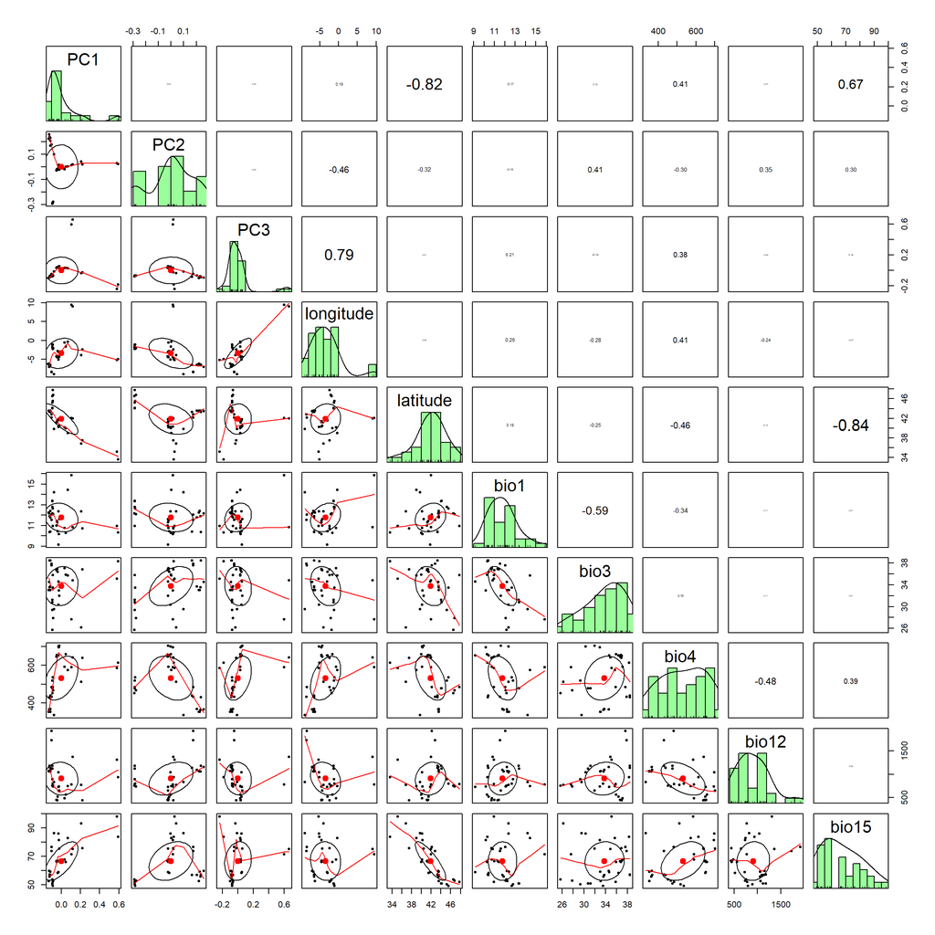

```r
fig_options <- list(
  path = "figs/ExploratoryAnalyses/CorrplotSelectedClimVariables.png",
  width=900,
  height=900,
  res=100)

corrplot_var <- colnames(listdf_pop$df)[colnames(listdf_pop$df) %in% c("longitude","latitude","PC1","PC2","PC3",global_var$variables)]

make_corrplot(df = listdf_pop$df,#
              variables = corrplot_var, # we keep long, lat, elev and clim variables
              fig_options = fig_options)

listdf_pop$df %>%
  dplyr::select(all_of(corrplot_var)) %>%
  unique() %>%
  pairs.panels(scale=T,hist.col="palegreen1")
```

```r
# Define the colors associated with each climatic variable for the following visualizations
color_clim_var <- c('#1f78b4','#a6cee3','#6a3d9a','#e31a1c','#33a02c','#ffff33','#fb9a99') %>%
  setNames(c(global_var$variables, drought_var$variables) %>% unique())
```

# 3 Variance partitioning

We want to disentangle the *relative contribution* of different factors in explaining genetic variation, namely:

- *climate*, either captured by the *summer-drought* climate variables or the *global* climate variables.
- *neutral population structure*, captured by the ancestry coefficients from Jaramillo-Correa et al. (2015).
- *geography*, accounted for by the population coordinates (longitude and latitude).

We will run:

- one *full* RDA with all factors (population structure, environment and geographical distance), i.e. no variable conditioning.
- three *partial* RDA in which the factor of interest is conditioned by the other two factors.

```r
var_part <- function(df_geno, select_clim_var, df_var, scale_rda, center_rda){

# The df of the explanatory variables has to include only the variables included in the model
df_var <- df_var %>%
  dplyr::select(all_of(select_clim_var$variables),
                starts_with("Q"),
                starts_with("PC"),
                ends_with("itude"))


# Build formulas of the RDA models
# ================================
form_clim_var <- paste(select_clim_var$variables,collapse= " + ") # climatic variables
form_pgs_var <- colnames(df_var) %>% stringr::str_subset("^Q|^PC") %>%  paste(collapse= " + ") # pop structure
form_geo_var <- colnames(df_var) %>% stringr::str_subset("itude") %>%  paste(collapse= " + ") # coordinates

# complete model formulas
form_full_rda <- paste("df_geno ~ ",
                       paste(c(form_clim_var,form_pgs_var,form_geo_var),collapse=" + " )) %>%
  as.formula()

form_clim_rda <- paste("df_geno ~ ",
                       form_clim_var,"+ Condition(",paste(c(form_pgs_var,form_geo_var),collapse=" + " ), ")") %>%
  as.formula()

form_pgs_rda <- paste("df_geno ~ ",
                       form_pgs_var,"+ Condition(",paste(c(form_clim_var,form_geo_var),collapse=" + " ), ")") %>%
  as.formula()

form.geo_rda <- paste("df_geno ~ ",
                       form_geo_var,"+ Condition(",paste(c(form_clim_var,form_pgs_var),collapse=" + " ), ")") %>%
  as.formula()


# Run the RDA models
# ==================

# Full RDA
full_rda <- rda(form_full_rda,
                data=df_var,
                scale=scale_rda,
                center=center_rda)
anova_full_rda <- anova(full_rda)

# Partial RDA: pure climatic model
clim_rda <- rda(form_clim_rda,
                data=df_var,
                scale=scale_rda,
                center=center_rda)
anova_clim_rda <- anova(clim_rda)

# Partial RDA: pure neutral population structure model
pgs_rda <- rda(form_pgs_rda,
                data=df_var,
                scale=scale_rda,
                center=center_rda)
anova_pgs_rda <- anova(pgs_rda)

# Partial RDA: pure geography model
geo_rda <- rda(form.geo_rda,
                data=df_var,
                scale=scale_rda,
                center=center_rda)
anova_geo_rda <- anova(geo_rda)


# Summary table
# =============

sum_tab_RDA <- tibble("RDA models"=c("Full model: Y ~ clim + geo + pgs.",
                      "Pure climate model: Y ~ clim | (geo + pgs)",
                      "Pure pop. gen. structure model: Y ~ pgs | (geo + clim)",
                      "Pure geography model: Y ~ geo | (pgs + clim)"),
       "Total exp. variance"=c(RsquareAdj(full_rda)[[1]],
              RsquareAdj(clim_rda)[[1]],
              RsquareAdj(pgs_rda)[[1]],
              RsquareAdj(geo_rda)[[1]]),
       "Relative exp. variance"=c(1,
                                  RsquareAdj(clim_rda)[[1]]/RsquareAdj(full_rda)[[1]],
                                  RsquareAdj(pgs_rda)[[1]]/RsquareAdj(full_rda)[[1]],
                                  RsquareAdj(geo_rda)[[1]]/RsquareAdj(full_rda)[[1]]),
       "P-value"=c(anova_full_rda[["Pr(>F)"]][[1]],
                   anova_clim_rda[["Pr(>F)"]][[1]],
                   anova_pgs_rda[["Pr(>F)"]][[1]],
                   anova_geo_rda[["Pr(>F)"]][[1]]))

# Export the table in latex
xtable(sum_tab_RDA, type = "latex",digits=2) %>%
  print(file = paste("tables/VariancePartitioningRDA_",select_clim_var$code,".tex"), include.rownames=FALSE)

return(sum_tab_RDA)
}
```

## 3.1 Individual-based allele counts

```r
list_sum_var_part <- lapply(list(global_var,drought_var), function(x){

  var_part(df_geno=geno_ind,
          select_clim_var=x,
          df_var=listdf_ind$dfsc %>% as_tibble(),
          scale_rda=F,center_rda=F)
}) %>% setNames(c(global_var$name,drought_var$name))

saveRDS(list_sum_var_part, file="outputs/RDA/SummaryVartPartIndividualLevel.rds")
```

```r
list_sum_var_part <- readRDS(file="outputs/RDA/SummaryVartPartIndividualLevel.rds")

# Global-climate variables
kable_mydf(list_sum_var_part[[1]], boldfirstcolumn = T)


# Summer-drought climatic variables
kable_mydf(list_sum_var_part[[2]], boldfirstcolumn = T)
```

[output not shown]

## 3.2 Population-based allele frequencies

```r
list_sum_var_part <- lapply(list(global_var,drought_var), function(x){

  var_part(df_geno=geno_pop,
           select_clim_var=x,
           df_var=listdf_pop$dfsc,
           scale_rda=F,center_rda=F)
}) %>% setNames(c(global_var$name,drought_var$name))

saveRDS(list_sum_var_part, file="outputs/RDA/SummaryVartPartPopLevel.rds")
```

```r
list_sum_var_part <- readRDS(file="outputs/RDA/SummaryVartPartPopLevel.rds")

# Global-climate variables
kable_mydf(list_sum_var_part[[1]], boldfirstcolumn = T)
```

| RDA models | Total exp. variance | Relative exp. variance | P-value |
| --- | --- | --- | --- |
| Full model: Y ~ clim + geo + pgs. | 0.7397793 | 1.0000000 | 0.001 |
| Pure climate model: Y ~ clim \| (geo + pgs) | 0.0855766 | 0.1156786 | 0.005 |
| Pure pop. gen. structure model: Y ~ pgs \| (geo + clim) | 0.2159452 | 0.2919049 | 0.001 |
| Pure geography model: Y ~ geo \| (pgs + clim) | 0.0356178 | 0.0481466 | 0.024 |

```r
# Summer-drought climatic variables
kable_mydf(list_sum_var_part[[2]], boldfirstcolumn = T)
```

| RDA models | Total exp. variance | Relative exp. variance | P-value |
| --- | --- | --- | --- |
| Full model: Y ~ clim + geo + pgs. | 0.6828822 | 1.0000000 | 0.001 |
| Pure climate model: Y ~ clim \| (geo + pgs) | 0.0286795 | 0.0419978 | 0.185 |
| Pure pop. gen. structure model: Y ~ pgs \| (geo + clim) | 0.2571711 | 0.3765966 | 0.001 |
| Pure geography model: Y ~ geo \| (pgs + clim) | 0.0446080 | 0.0653231 | 0.002 |

# 4 Identifying loci under selection

## 4.1 Run the RDA

We perform RDA models the four combinations of the two sets of selected climatic variables and accounting or not for the neutral genetic population structure:

- Allele frequencies ~ global climatic variables + Condition(PC1 + PC2 + PC3)
- Allele frequencies ~ global climatic variables
- Allele frequencies ~ drought-summer variables + Condition(PC1 + PC2 + PC3)
- Allele frequencies ~ drought-summer variables

RDA summary statistics are summarized in the pdfs `RDAsummary.pdf` and the RDA plots colored by gene pool are shown in the pdfs `RDAplots.pdf`.

```r
# =========
# FUNCTIONS
# =========


# Function to create a S3 object with the RDA model and some info
# ===============================================================
new_RDA <- function(form_rda,selected_var,PCs,mod_rda,r2,eigenvalues,model_significance,axis_significance,vif){

  structure(
    .Data = list(form_rda=form_rda,
                 selected_var=selected_var,
                 PCs=PCs,
                 mod_rda=mod_rda,
                 r2=r2,
                 eigenvalues=eigenvalues,
                 model_significance=model_significance,
                 axis_significance=axis_significance,
                 vif=vif),
    creation_time = Sys.time(),
    class = "myrda"
  )
  }



# Function to print S3 object of class 'myrda'
# ============================================
print.myrda <- function(x,...){

  print_message <- c(
    paste0("  RDA formula: ", x$form_rda),
    paste0("  Creation time: ", format(attr(x, "creation_time"))),
    paste0(c("  List elements:", names(x)),collapse="   ")
    )

  cat(
    print_message,
    sep = "\n"
  )

}


# Function to run the RDA models and store the info in a S3 object of class 'myrda'
# =================================================================================
runRDA <- function(df,geno_pop,selected_var,pop_structure_correction){



  # write RDA formulas
form_clim_var <- paste(selected_var$variables,collapse= " + ")
if(pop_structure_correction==T) {
  PCs <- colnames(df) %>% stringr::str_subset("^PC")
  form_pgs_var <- PCs %>%  paste(collapse= " + ")
  form_rda <- paste("geno_pop ~ ", form_clim_var,"+ Condition(",paste(c(form_pgs_var),collapse=" + " ), ")")
} else {
  PCs = NULL
  form_rda <- paste("geno_pop ~ ", form_clim_var)
  }
mod_rda <- rda(as.formula(form_rda), df)
r2 <- RsquareAdj(mod_rda)
eigenvalues <- summary(eigenvals(mod_rda, model = "constrained"))
model_significance <- anova.cca(mod_rda, parallel=getOption("mc.cores")) # default is permutation=999
axis_significance <- anova.cca(mod_rda, by="axis", parallel=getOption("mc.cores"))
vif <- vif.cca(mod_rda)

return(new_RDA(form_rda=form_rda,
               selected_var=selected_var,
               PCs=PCs,
               mod_rda=mod_rda,
               r2=r2,
               eigenvalues=eigenvalues,
               model_significance=model_significance,
               axis_significance=axis_significance,
               vif=vif))

}



# Function to generate a pdf with the RDA model outputs
# =====================================================
viz_RDAsummary <- function(x){

  # check the class of x
  stopifnot("x is not of class myrda" = class(x)=="myrda")

  # Generate R2 table
r2_tab <- x$r2 %>%
  as.data.frame() %>%
  pivot_longer(everything()) %>%
  column_to_rownames(var ="name") %>%
  round(2) %>%
  ggtexttable(rows = row.names(.),cols = NULL, theme = ttheme("blank"))

  # Generate table of eigenvalues and proportion of variance explained
eigenvalues_tab <- x$eigenvalues %>%
  as.data.frame() %>%
  round(2) %>%
  ggtexttable(rows = rownames(.), theme = ttheme("blank")) %>%
  tab_add_hline(at.row = 1:2, row.side = "top", linewidth = 2)

  # Generate table of model and axis significance
signi_tab <- bind_rows(as.data.frame(x$model_significance[-nrow(x$model_significance),]),
          as.data.frame(x$axis_significance[-nrow(x$axis_significance),])) %>%
  dplyr::mutate(across(!Df, ~ round(.x,3))) %>%
  ggtexttable(rows = rownames(.), theme = ttheme("blank")) %>%
  tab_add_hline(at.row = 1:2, row.side = "top", linewidth = 2) %>%
  tab_add_hline(at.row = 3, row.side = "top", linewidth = 0.01)

  # Generate table for VIF (Variance Inflation Factors)
vif_tab <- x$vif %>%
  as.data.frame() %>%
  round(2) %>%
  rownames_to_column("Variable") %>%
  pivot_wider(values_from=".", names_from = "Variable") %>%
  ggtexttable(rows = "VIF", theme = ttheme("blank")) %>%
  tab_add_hline(at.row = 2, row.side = "top", linewidth = 2)

  # Generate the screeplot of the eigenvalues
ggscreeplot <- x$eigenvalues %>% #
  as.data.frame() %>%
  dplyr::filter(row.names(.) == "Eigenvalue")  %>%
  pivot_longer(everything(),names_to="PC",values_to="eigenvalues") %>%
  ggplot(aes(x= PC,
             y=eigenvalues,
             group=1)) +
  geom_point(size=4)+
  geom_line() +
  ylab("Eigen values") + xlab("") +
  labs(title="Scree plot") +
  theme_bw()


ggarrange(ggarrange(r2_tab,signi_tab,vif_tab,nrow=3),
           ggarrange(eigenvalues_tab,ggscreeplot,nrow=2),
           nrow = 1,
           ncol = 2) %>%
annotate_figure(top = text_grob(x$form_rda,
                                size = 16,
                                color = 'black',
                                face = 'bold'))

}


# Function to plot the RDA models
# ==============================
plot_RDA <- function(df,x){

  # check the class of x
  stopifnot("x is not of class myrda" = class(x)=="myrda")

  # The genotypes points are colored based on the main gene pool the belong to.
  bg <- c("orangered3","gold2","darkorchid3","navyblue","turquoise2","green3") # define the colors
  GPs <- df$mainGPpop %>%  as.factor()
  levels(GPs) <- list("Northern Africa" = "Q1",
                      "Corsica" = "Q2",
                      "Central Spain" = "Q3",
                      "French Atlantic" = "Q4",
                      "Iberian Atlantic" = "Q5",
                      "South-eastern Spain" = "Q6")

  if(x$axis_significance %>% as.data.frame() %>% nrow()-1>2) {
  par(mfrow=c(1,2))
  rdaplots <-  lapply(2:3, function(second.axis){
    plot(x$mod_rda, type="n", scaling=3, choices=c(1,second.axis))
    points(x$mod_rda, display="species", pch=20, cex=0.7, col="gray32", scaling=3, choices=c(1,second.axis))
    points(x$mod_rda, display="sites", pch=21, cex=1.3, col="gray32", scaling=3, bg=bg[GPs], choices=c(1,second.axis))
    text(x$mod_rda, scaling=3, display="bp", col="#0868ac", cex=1, choices=c(1,second.axis))
    if(second.axis==2) legend("topleft", legend=levels(GPs), bty="n", col="gray32", pch=21, cex=1, pt.bg=bg)
    recordPlot()
  })} else {
    par(mfrow=c(1,1))
    plot(x$mod_rda, type="n", scaling=3, choices=c(1,2))
    points(x$mod_rda, display="species", pch=20, cex=0.7, col="gray32", scaling=3, choices=c(1,2))
    points(x$mod_rda, display="sites", pch=21, cex=1.3, col="gray32", scaling=3, bg=bg[GPs], choices=c(1,2))
    text(x$mod_rda, scaling=3, display="bp", col="#0868ac", cex=1, choices=c(1,2))
    legend("bottomright", legend=levels(GPs), bty="n", col="gray32", pch=21, cex=1, pt.bg=bg)
  }

  title(x$form_rda, line=-3,outer = TRUE)
}
```

```r
# We store in a list the four combinations of:
  # - the two sets of selected climatic variables
  # - correction or not by population structure
rda_combinations <- list(
  list(selected_var = global_var,
       pop_structure_correction = FALSE),
  list(selected_var = global_var,
       pop_structure_correction = TRUE),
  list(selected_var = drought_var,
       pop_structure_correction = FALSE),
  list(selected_var = drought_var,
       pop_structure_correction = TRUE))


# Run the RDA models and store their information
rda_models <- lapply(rda_combinations, function(x){
  runRDA(df = listdf_pop$dfsc,
         geno_pop = geno_pop,
         selected_var = x$selected_var,
         pop_structure_correction = x$pop_structure_correction)})

# save the RDA models and their information
saveRDS(rda_models, "outputs/RDA/RDAmodels.rds")

# viz RDA models and their summary information
pdf(width = 10, height = 6, "figs/RDA/RDAsummary.pdf")
lapply(rda_models, viz_RDAsummary)
dev.off()


# plot RDA models
pdf(width = 12, height = 8, "figs/RDA/RDAplots.pdf")
lapply(rda_models, function(x) plot_RDA(df=listdf_pop$dfsc,x=x))
dev.off()
```

## 4.2 Identify outliers

Two ways of identifying the outliers with the RDA:

- identifying outliers based on their *extremeness* along a *distribution of Mahalanobis distances* estimated between each locus and the center of the RDA space using a certain number of axes (K). Method used in Capblancq et al. (2020) (see [code](https://github.com/Capblancq/Local-Adaptation-Fagus-sylvatica)) and Capblancq and Forester (2021) ([code](https://github.com/Capblancq/RDA-landscape-genomics)). To conduct the RDA-based genome scan, we use the `rdadapt` function from Capblancq and Forester (2021).
- identifying RDA outliers is to search for *extreme loadings on each retained axis*. Method used in Forester et al. (2018) (see [code](https://popgen.nescent.org/2018-03-27_RDA_GEA.html)

```r
# ====================================
# Function to identify the outlier SNPs
# =====================================

identify_outliers <- function(rda_model, explanatory_data, geno_data){

# outlier detection based on  extreme Mahalanobis distances from the RDA center
# =============================================================================

# Genome scan with K = 2 (degrees of freedom of the X2 distribution)
GSout <- rdadapt(rda_model$mod_rda, 2) %>%  # rdadapt is a function to conduct a RDA based genome scan (from Capblancq & Forester 2021)
  mutate(snp=colnames(geno_data))

# P-values threshold after Bonferroni correction
outliers_maha <- GSout %>%
  filter(pvalues <  0.01/length(pvalues)) %>%
  mutate(maha_meth = TRUE) %>%
  dplyr::select(snp,maha_meth) # we do not keep the p.values and q.values in the outlier table


# outlier detection based on  extreme axis loadings
# =================================================

nb_signi_axis <- rda_model$axis_significance %>%
  as.data.frame() %>%
  dplyr::rename(pvalue="Pr(>F)") %>%
  dplyr::filter(pvalue<0.05) %>%
  nrow()

loads <- scores(rda_model$mod_rda, choices=c(1:(nrow(as.data.frame(rda_model$axis_significance))-1)), display="species")


outliers_loads <- lapply(1:nb_signi_axis, function(id.axis){
  out <- detectoutliers(loads[,id.axis],3) # function to identify outliers based on their RDA loadings (from  Forester et al. 2018)
  tibble(
    #axis=rep(id.axis,times=length(out)), # we do not keep the information about the axis
    snp = names(out),
    load_meth = TRUE,
    # loading = out # we do not keep the loadings
  )
}) %>%
  list_rbind() %>%
  distinct()



# Merge outliers identified by the two methods
# ============================================

all_outliers <- full_join(outliers_maha,outliers_loads, by="snp") %>%
  mutate(across(c(maha_meth,load_meth), ~replace_na(.,FALSE)))

all_outliers <- map(all_outliers$snp, function(snp){
 cordf <-  cor(explanatory_data[,names(rda_model$vif)],geno_data[,snp]) %>%
    as.data.frame() %>%
    rownames_to_column() %>%
    pivot_wider(names_from="rowname", values_from = "V1") %>%
     mutate(max_var = names(which.max(abs(.)))) %>%
     mutate(max_var_clim = names(which.max(abs(.[,rda_model$selected_var$variables]))))
}) %>%
  setNames(all_outliers$snp) %>%
  list_rbind(names_to = "snp") %>%
  inner_join(all_outliers,by="snp")


list(rda_model = rda_model,
     GSout = GSout, # keep the p.values for the Manhattan plot
     outliers = all_outliers)

}
```

```r
# we identify the outlier SNPs for the four RDA models
rda_outliers <- rda_models %>%
  lapply(function(x) {
    identify_outliers(rda_model = x, explanatory_data = listdf_pop$dfsc, geno_data = geno_pop)
  })

saveRDS(rda_outliers, "outputs/RDA/RDA_outliers.rds")
```

## 4.3 Outlier visualization

### 4.3.1 RDA plots based on Forester et al. (2018)

We visualize the outliers with RDA plots following Forester et al. (2018) (see [code](https://popgen.nescent.org/2018-03-27_RDA_GEA.html)). Figures are stored in `RDAplots_outliers_1.pdf`.

```r
# Function to make one RDA plot with different colors for outlier SNPs
make_one_outlier_rda_plot <- function(mod_rda, data_plots, xlim, ylim, second_axis,arrow_length,outline_col){

plot(mod_rda, type="n", scaling=3, xlim=xlim, ylim=ylim, choices=c(1,second_axis))
points(mod_rda, display="species", pch=21, cex=1, col=data_plots$allsnps$nooutlier_color, bg=data_plots$allsnps$nooutlier_bg , scaling=3, choices=c(1,second_axis))
points(mod_rda, display="species", pch=21, cex=1, col=data_plots$allsnps$outlier_color, bg=data_plots$allsnps$outlier_bg, scaling=3, choices=c(1,second_axis))
text(mod_rda, scaling=3, display="bp", col="#0868ac", cex=1, arrow.mul=arrow_length, choices=c(1,second_axis))
legend("topleft", legend=data_plots$legend_names, bty="n", col=outline_col, pch=21, cex=1, pt.bg=data_plots$legend_colors,ncol=1,title=data_plots$legend_title)
recordPlot()

}




# Function that combines two types of plot:
  # plots in which outliers are colored according to their most associated climatic variable
  # plots in which outliers are colored according to the detection method used to identify them:
      # a method based on the Mahalanobis distances from the center of the RDA space
      # a method based on the extreme SNP loadings on each significant axis
combine_rda_outlier_plots <- function(rda_out,color_clim_var){

# Storing data and options to generate the plots in a list
list_data_plots <- list(clim=list(), # options/data specific to plots with colors based on the climatic variables
                        meth=list()) # options/data specific to plots with colors based on the detection methods


# Figure options shared between the two types of plot
# ===================================================

nooutliers_bg <- '#f1eef6'
outline_col <- 'gray32'
transparent_col <- rgb(0,1,0, alpha=0)



# Fig options/data specific to plots based on the climatic variables
# ==================================================================

# Attribute one color to each climatic variable
selected_var_colors <- tibble(max_var_clim = names(color_clim_var),
                              outlier_bg = color_clim_var) %>%
  dplyr::filter(max_var_clim %in% rda_out$rda_model$selected_var$variables)

# Generate a dataframe with color information for outliers
outlier_colors <-  rda_out$outliers %>%
  dplyr::select(snp, max_var_clim) %>%
  left_join(selected_var_colors, by="max_var_clim")

# Generate a dataframe with color information for all SNPs
list_data_plots$clim$allsnps <- tibble(snp=rownames(rda_out$rda_model$mod_rda$CCA$v)) %>%
  left_join(outlier_colors, by="snp") %>%
  mutate(outlier_bg = replace_na(outlier_bg,transparent_col),
         outlier_color = ifelse(outlier_bg == transparent_col, transparent_col, outline_col),
         nooutlier_bg = ifelse(outlier_bg == transparent_col, nooutliers_bg, transparent_col),
         nooutlier_color = ifelse(outlier_bg == transparent_col, outline_col, transparent_col))

# Legend options
list_data_plots$clim$legend_title <- 'Climatic variable'
list_data_plots$clim$legend_names <- selected_var_colors$max_var_clim
list_data_plots$clim$legend_colors <- selected_var_colors$outlier_bg


# Fig options/data specific to plots based on the detection methods
# =================================================================

# Attribute one color to each method
method_colors <- c('#FCF926','#3BCD24','#CD24B2') %>% setNames(c("Mahalanobis distance","Axis loadings", "Both"))

# Legend options
list_data_plots$meth$legend_colors <- method_colors
list_data_plots$meth$legend_names <- names(method_colors)
list_data_plots$meth$legend_title <- 'Outlier detection method'


# attribute colors to all SNPs
list_data_plots$meth$allsnps <-  tibble(snp=rownames(rda_out$rda_model$mod_rda$CCA$v)) %>%
  left_join(rda_out$outliers[,c("snp", "load_meth", "maha_meth")],by="snp") %>%
  mutate(outlier_bg = case_when(load_meth == TRUE & maha_meth == TRUE ~ method_colors["Both"],
                                load_meth == TRUE & maha_meth == FALSE ~ method_colors["Axis loadings"],
                                load_meth == FALSE & maha_meth == TRUE ~ method_colors["Mahalanobis distance"],
                                is.na(load_meth) & is.na(maha_meth) ~ transparent_col),
         outlier_color = ifelse(outlier_bg == transparent_col, transparent_col, outline_col),
         nooutlier_bg = ifelse(outlier_bg == transparent_col, nooutliers_bg, transparent_col),
         nooutlier_color = ifelse(outlier_bg == transparent_col, outline_col, transparent_col))


# Generate the RDA plots
# =====================

# For RDA models with 2 explanatory variables, we can only plot RDA1 vs RDA2

if(rda_out$rda_model$axis_significance %>% as.data.frame() %>% nrow()-1>2) { # rda models with more than 2 climatic variables

par(mfrow=c(2,2))
lapply(2:3, function(second_axis){ # generate two plots: RDA1 vs RDA2 and RDA1 vs RDA3
    lapply(list_data_plots, function(x) make_one_outlier_rda_plot(mod_rda = rda_out$rda_model$mod_rda,
                                                                  data_plots = x,
                                                                  xlim=c(-1,1),
                                                                  ylim=c(-0.5,0.5),
                                                                  arrow_length=1.25,
                                                                  outline_col=outline_col,
                                                                  second_axis=second_axis))

  })} else {  # rda models with 2 climatic variables

par(mfrow=c(1,2))
    lapply(list_data_plots, function(x) make_one_outlier_rda_plot(mod_rda = rda_out$rda_model$mod_rda,
                                                                  data_plots = x,
                                                                  xlim=c(-0.3,0.3),
                                                                  ylim=c(-0.5,0.5),
                                                                  outline_col=outline_col,
                                                                  arrow_length=0.6,
                                                                  second_axis=2))

  }

  title(rda_out$rda_model$form_rda, line=-3,outer = TRUE) # rda model formula as title

}
```

```r
# Plot RDA outliers with different colors based either on the detection method or the most associated climatic variable
pdf(width = 12, height = 8, "figs/RDA/RDAplots_outliers_1.pdf")
lapply(rda_outliers, function(x) combine_rda_outlier_plots(rda_out = x,color_clim_var = color_clim_var))
dev.off()
```

### 4.3.2 RDA plots based on Capblancq and Forester (2021)

We visualize the outliers with RDA and Manhattan plots following Capblancq and Forester (2021) ([code](https://github.com/Capblancq/RDA-landscape-genomics)). Figures are stored in `RDAplots_outliers_2.pdf`.

```r
make_rda_ggplot <- function(data_plots,TAB_var){

  data_plots$tab[order(data_plots$tab$snp_type),] %>%
  ggplot() +
  geom_hline(yintercept=0, linetype="dashed", color = gray(.80), linewidth=0.6) +
  geom_vline(xintercept=0, linetype="dashed", color = gray(.80), linewidth=0.6) +
  geom_point(aes(x=RDA1*20, y=RDA2*20, colour = snp_type), size = 1.4) +
  scale_color_manual(values = data_plots$legend_colors) +
  geom_segment(data = TAB_var, aes(xend=RDA1, yend=RDA2, x=0, y=0),
               colour="black", linewidth=0.15, linetype=1, arrow=arrow(length = unit(0.02, "npc"))) +
  geom_text(data = TAB_var, aes(x=1.1*RDA1, y=1.1*RDA2, label = row.names(TAB_var)), size = 2.5) +
  xlab("RDA 1") + ylab("RDA 2") +
  facet_wrap(~"RDA space") +
  guides(color=guide_legend(title=data_plots$legend_title)) +
  theme_bw(base_size = 11) +
  theme(panel.background = element_blank(),
        legend.background = element_blank(),
        panel.grid = element_blank(),
        plot.background = element_blank(),
        legend.text=element_text(size=rel(.8)),
        strip.text = element_text(size=11))



}

make_manhattan_plot <- function(data_plots){

data_plots$tab[order(data_plots$tab$snp_type),] %>%
ggplot() +
  geom_hline(yintercept=-log10(0.01/length(data_plots$tab$pvalues)), linetype="dashed", color = gray(.80), linewidth=0.6) +
  geom_point(aes(x=pos, y=-log10(pvalues), col = snp_type), size=1.4) +
  scale_color_manual(values = data_plots$legend_colors) +
  xlab("Loci") + ylab("-log10(p-values)") +
  facet_wrap(~"Manhattan plot", nrow = 3) +
  guides(color=guide_legend(title=data_plots$legend_title)) +
  theme_bw(base_size = 11, base_family = "Times") +
  theme(legend.position="right", legend.background = element_blank(), panel.grid = element_blank(), legend.box.background = element_blank(), plot.background = element_blank(), panel.background = element_blank(), legend.text=element_text(size=rel(.8)), strip.text = element_text(size=11))
  }


# Function that combines two types of plot:
  # plots in which outliers are colored according to their most associated climatic variable
  # plots in which outliers are colored according to the detection method used to identify them:
      # a method based on the Mahalanobis distances from the center of the RDA space
      # a method based on the extreme SNP loadings on each significant axis
combine_rda_outlier_ggplots <- function(rda_out,color_clim_var){

# Storing data and options to generate the plots in a list
list_data_plots <- list(clim=list(), # options/data specific to plots with colors based on the climatic variables
                        meth=list()) # options/data specific to plots with colors based on the detection methods


# Figure options shared between the two types of plot
# ===================================================

nooutliers_bg <- "gray90"
nooutliers_legend <- "No detection"

locus_scores <- scores(rda_out$rda_model$mod_rda, choices=c(1:2),
                       display="species", # 'species' in the vegan package correspond to the loci
                       scaling="none") %>%
  as.data.frame() %>%
  rownames_to_column("snp") %>%
  as_tibble() %>%
  inner_join(rda_out$GSout, by="snp") %>%
  mutate(pos=seq(1:nrow(.)))

TAB_var <- as.data.frame(scores(rda_out$rda_model$mod_rda, choices=c(1,2), display="bp"))

# Fig options/data specific to plots based on the climatic variables
# ==================================================================

# Legend options
vec_color_clim_var <- color_clim_var[names(color_clim_var) %in% unique(rda_out$outliers$max_var_clim)]
list_data_plots$clim$legend_title <- 'Climatic variable'
list_data_plots$clim$legend_names <- c(nooutliers_legend,names(vec_color_clim_var))
list_data_plots$clim$legend_colors <- c(nooutliers_bg,vec_color_clim_var) %>% unname()


list_data_plots$clim$tab <-  locus_scores %>%
  left_join(rda_out$outliers[,c("snp", "max_var_clim")],by="snp") %>%
  mutate(max_var_clim = replace_na(max_var_clim,nooutliers_legend)) %>%
  mutate(max_var_clim =factor(max_var_clim,levels=list_data_plots$clim$legend_names)) %>%
  dplyr::rename(snp_type = max_var_clim)


# Fig options/data specific to plots based on the detection methods
# =================================================================


# Legend options
list_data_plots$meth$legend_colors <- c(nooutliers_bg,'#FCF926','#3BCD24','#CD24B2')
list_data_plots$meth$legend_names <- c(nooutliers_legend,"Mahalanobis distance","Axis loadings", "Both")
list_data_plots$meth$legend_title <- 'Outlier detection'


list_data_plots$meth$tab <-   locus_scores %>%
  left_join(rda_out$outliers[,c("snp", "load_meth", "maha_meth")],by="snp") %>%
  mutate(snp_type = case_when(load_meth == TRUE & maha_meth == TRUE ~  list_data_plots$meth$legend_names[[4]],
                              load_meth == TRUE & maha_meth == FALSE ~ list_data_plots$meth$legend_names[[3]],
                              load_meth == FALSE & maha_meth == TRUE ~ list_data_plots$meth$legend_names[[2]],
                              is.na(load_meth) & is.na(maha_meth) ~ list_data_plots$meth$legend_names[[1]])) %>%
  mutate(snp_type=factor(snp_type,levels=list_data_plots$meth$legend_names))



# Generate the RDA plots
# =====================


p1 <- lapply(list_data_plots, function(x) make_rda_ggplot(data_plots = x,
                                                         TAB_var=TAB_var))

p2 <- lapply(list_data_plots, function(x) make_manhattan_plot(data_plots = x))

plot_row <- plot_grid(p1$clim, p1$meth,p2$clim,p2$meth, ncol=2)

# Title options
title <- ggdraw() +
  draw_label(
    rda_out$rda_model$form_rda,
    fontface = 'bold',
    x = 0,
    hjust = 0
  ) +
  theme(
    # add margin on the left of the drawing canvas,
    # so title is aligned with left edge of first plot
    plot.margin = margin(0, 0, 0, 7)
  )

# merge title and plots
plot_grid(
  title, plot_row,
  ncol = 1,
  # rel_heights values control vertical title margins
  rel_heights = c(0.1, 1)
)


}
```

```r
# Plot RDA outliers with different colors based either on the detection method or the most asspciated climatic variable
pdf(width = 12, height = 8, "figs/RDA/RDAplots_outliers_2.pdf")
lapply(rda_outliers, function(x) combine_rda_outlier_ggplots(rda_out = x, color_clim_var=color_clim_var))
dev.off()
```

## 4.4 Common outliers

We identify the common outliers among the four RDA models with Venn diagrams.

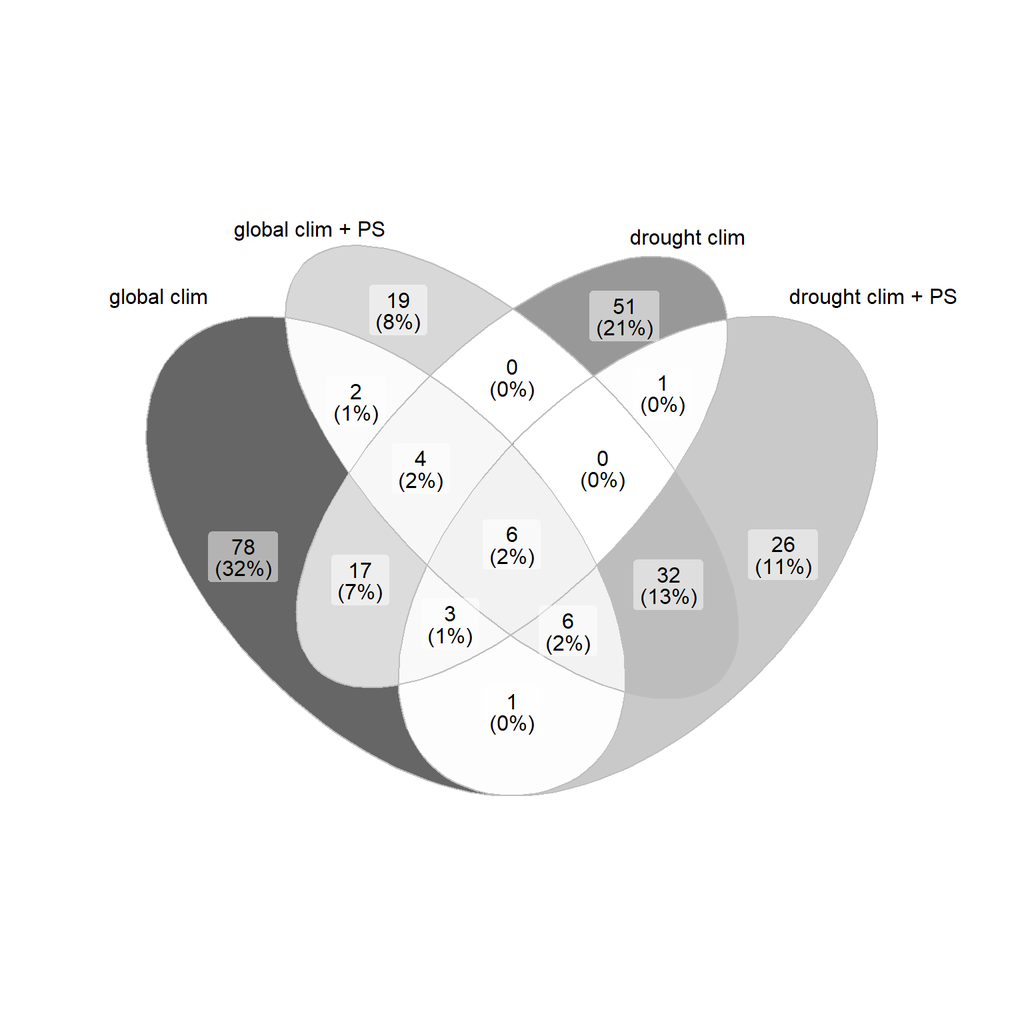

```r
list_outliers <- list("global clim" = rda_outliers[[1]]$outliers$snp,
                      "global clim + PS" = rda_outliers[[2]]$outliers$snp,
                      "drought clim" = rda_outliers[[3]]$outliers$snp,
                      "drought clim + PS" = rda_outliers[[4]]$outliers$snp)

p <- ggVennDiagram(list_outliers,lty="solid", size=0.2) +
  scale_fill_gradient2(low = "white", high = 'gray40') + scale_color_manual(values = c("grey", "grey", "grey", "grey")) +
  guides(fill = "none") +
  theme(text = element_text(size=16)) +
  scale_x_continuous(expand = expansion(mult = .2))

ggsave("figs/RDA/VennDiagramOutliers.pdf",p)

p
```

# References

Capblancq, Thibaut, and Brenna R Forester. 2021. “Redundancy Analysis (RDA): A Swiss Army Knife for Landscape Genomics.” *Methods in Ecology and Evolution*.

Capblancq, Thibaut, Xavier Morin, Maya Gueguen, Julien Renaud, Stéphane Lobreaux, and Eric Bazin. 2020. “Climate-Associated Genetic Variation in Fagus Sylvatica and Potential Responses to Climate Change in the French Alps.” *Journal of Evolutionary Biology* 33 (6): 783–96.

Forester, Brenna R, Jesse R Lasky, Helene H Wagner, and Dean L Urban. 2018. “Comparing Methods for Detecting Multilocus Adaptation with Multivariate Genotype–Environment Associations.” *Molecular Ecology* 27 (9): 2215–33.

Grivet, Delphine, Federico Sebastiani, Ricardo Alı́a, Thomas Bataillon, Sara Torre, Mario Zabal-Aguirre, Giovanni G Vendramin, and Santiago C González-Martı́nez. 2011. “Molecular Footprints of Local Adaptation in Two Mediterranean Conifers.” *Molecular Biology and Evolution* 28 (1): 101–16.

Jaramillo-Correa, Juan-Pablo, Isabel Rodrı́guez-Quilón, Delphine Grivet, Camille Lepoittevin, Federico Sebastiani, Myriam Heuertz, Pauline H Garnier-Géré, et al. 2015. “Molecular Proxies for Climate Maladaptation in a Long-Lived Tree (Pinus Pinaster Aiton, Pinaceae).” *Genetics* 199 (3): 793–807.